# CoreBioPathways

Data Analytics, Bioinformatics, Molecular Biology, Subject Matter Expertise, Laboratory Cost Reduction

[Github](https://github.com) [LinkedIn](https://linkedin.com/in/abuckley2)

# Check out https://www.corebiopathways.com

## Mission

CoreBioPathways aims to provide scientific guidance and data analysis to clients with an emphasis on experimental vigor and actionable insights based on client needs.

## Services we offer

- Bioinformatics analysis of projects; genomics, transcriptomics, proteomics
- Bioanalytical assay analysis
- Data Analysis and Dissemination: Dashboard and App development, Machine learning Projects
- Subject matter expertise:microbiology, microbiomes, immunology, oncology, cell therapies, biological networks
- Laboratory operations: Equipment and consumable strategizing.

### Data Analytics

- Data analytics for biological studies
- R, python, Bash workflows
- Dashboards (dash, quarto) and application development (shiny)
- Data management and pipelines

### Bioinformatics

CoreBioPathways experts have experience with several bioinformatics analyses and workflows; including:

- Genomics (whole exome and whole genome sequencing)
- Transcriptomics (bulk and single cell RNAseq)
- Proteomics

### Laboratory Consulting

- Assessment of laboratory operations for cost reductions and efficiency improvements
- Laboratory operations, equipment, and consumable strategizing.
- Implementation of best practices in laboratory management
- Training and support for laboratory personnel in molecular biology techniques and data/programming

### Subject Matter Expertise

- In-depth knowledge in: Microbiology, Immunology, Microbiomes, Cell Therapies, Oncology, Bioinformatics, Automation development in R and Python
- Consultation on research projects, grant applications, and publications
- Literature reviews and white paper level strategy analysis

## Contact CoreBioPathways, LLC

#### **Phone:** +1-(980)-666-8491

#### **Email:** corebiopathways@gmail.com

#### **Inquiry Form**: [Here](https://forms.gle/jCW9QymH5W1U6ZQD8)

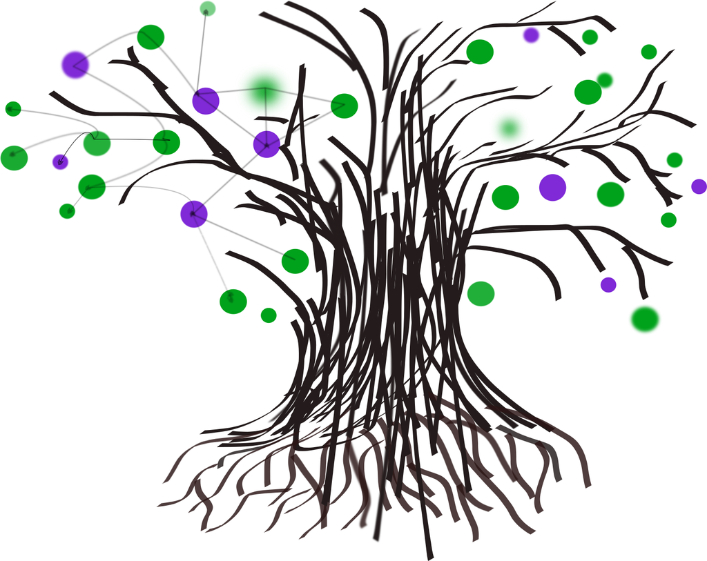